# Overview of R – Part I

### Data frames

Data frame is the most commonly used member of the data types family in R. A data frame is a generalization of a matrix, in which different columns may have different modes. All elements of any column must have the same mode, i.e. all numeric or all factor, or all character.

```r
dat.1 <- data.frame(class.names, age, grades, EPIB.student)
print(dat.1)
##         class.names age grades EPIB.student
## Robert       Robert  22     A+         TRUE
## Alice         Alice  21     A+         TRUE
## Mark           Mark  23     B+         TRUE
## Kate           Kate  22     B-        FALSE
## Charlie     Charlie  24     C+        FALSE
## Victor       Victor  21     A-         TRUE
## John           John  21     B+         TRUE

str(dat.1) # checking the structure of an object
## 'data.frame':    7 obs. of  4 variables:
##  $ class.names : Factor w/ 7 levels "Alice","Charlie",..: 6 1 5 4 2 7 3
##  $ age         : num  22 21 23 22 24 21 21
##  $ grades      : Factor w/ 5 levels "A-","A+","B-",..: 2 2 4 3 5 1 4
##  $ EPIB.student: logi  TRUE TRUE TRUE FALSE FALSE TRUE ...
```

```r
0/0
## [1] NaN

# We can also assign NaN values to data
dat.1$age <- c(22, 21, 23, 22, 24, NA, NA)
```

### Lists: special types of vectors

- Lists are like vectors, only the objects can be of different types
  - We can have a list of numbers or characters
  - We can have a list of some numbers, some characters and some logical
- Lists can also hold other data structures
  - We can have a list where each element is a vector
  - or a matrix
  - We could even have a list of lists!

```r
mylist <- list("Red", factor(c("a","b")), c(21,32,11), TRUE)
print(mylist)
## [[1]]
## [1] "Red"
##
## [[2]]
## [1] a b
## Levels: a b
##
## [[3]]
## [1] 21 32 11
##
## [[4]]
## [1] TRUE

str(mylist)
## List of 4
##  $ : chr "Red"
##  $ : Factor w/ 2 levels "a","b": 1 2
##  $ : num [1:3] 21 32 11
##  $ : logi TRUE
```

### Factors

- A lot like character vectors
  - They have an additional `levels` part to them
  - This type of data structure is useful with other R functions (later)

```r
ch.letter <- rep(letters[1:3], each = 4)
print(ch.letter)
##  [1] "a" "a" "a" "a" "b" "b" "b" "b" "c" "c" "c" "c"

class(ch.letter)
## [1] "character"

fac.letter <- rep(as.factor(letters[1:3]), each = 4)
print(fac.letter)
##  [1] a a a a b b b b c c c c
## Levels: a b c
# Note the additional 'Levels: a b c' in the output

class(fac.letter)
## [1] "factor"

levels(fac.letter) <- c("Alpha", "Bravo", "Charlie")
print(fac.letter)
##  [1] Alpha   Alpha   Alpha   Alpha   Bravo   Bravo   Bravo   Bravo
##  [9] Charlie Charlie Charlie Charlie
## Levels: Alpha Bravo Charlie
```

### Conversions between different types:

Conversion between these data structures - as.vector - as.matrix - as.array - as.data.frame - … Check whether your R object has certain data structure - is.vector - is.matrix - is.array - is.data.frame - …

## More on Operations

So far we have seen simple operations on scalars. R allows us to do much more with vectors and matrices.

### Numerical operations

```r
a <- c(1, 8, 8)
b <- c(2, 8, 4)

a+1 # here 1 is considered as a vector (1, 1, 1)
## [1] 2 9 9

a+b
## [1]  3 16 12

a*b
## [1]  2 64 32

a^2
## [1]  1 64 64

c <- matrix(c(1,2,3,4), nrow = 2, byrow = T)
d <- matrix(c(5,6,7,8), nrow = 2, byrow = F)
print(c); print(d)
##      [,1] [,2]
## [1,]    1    2
## [2,]    3    4
##      [,1] [,2]
## [1,]    5    7
## [2,]    6    8

c+1
##      [,1] [,2]
## [1,]    2    3
## [2,]    4    5

c+d
##      [,1] [,2]
## [1,]    6    9
## [2,]    9   12

c*d
##      [,1] [,2]
## [1,]    5   14
## [2,]   18   32

c^2
##      [,1] [,2]
## [1,]    1    4
## [2,]    9   16

a %*% b
##      [,1]
## [1,]   98

a %o% b
##      [,1] [,2] [,3]
## [1,]    2    8    4
## [2,]   16   64   32
## [3,]   16   64   32

c %*% d
##      [,1] [,2]
## [1,]   17   23
## [2,]   39   53

c; t(c)
##      [,1] [,2]
## [1,]    1    2
## [2,]    3    4
##      [,1] [,2]
## [1,]    1    3
## [2,]    2    4

diag(c)
## [1] 1 4

det(c)
## [1] -2
```

### Logical operators

```r
# Recall vector a and b from above.
print(a); print(b)
## [1] 1 8 8
## [1] 2 8 4

a == b # Equal or not?
## [1] FALSE  TRUE FALSE

a != b # Not equal?
## [1]  TRUE FALSE  TRUE

a > b
## [1] FALSE FALSE  TRUE

a <= b
## [1]  TRUE  TRUE FALSE

# And
a; b
## [1] 1 8 8
## [1] 2 8 4
a>5 & b>5
## [1] FALSE  TRUE FALSE

# Or
a>=5 | b>=5
## [1] FALSE  TRUE  TRUE

"ABC" == "ABC"
## [1] TRUE

"ABC" == "abc"
## [1] FALSE

TRUE + TRUE + FALSE # True = 1, False = 0.
## [1] 2
```

## Data viziulization

We will begin with some basic data visualization using the `ggformula` package.

```r
library(ggformula)
```

Basic idea for ggformula is as follows:

### FunctionName (Outcome Variable ~ Explanatory Variable(s), data = myData)

We will use a number of existing dataframes in R for this demonstration. To see list of available data sets in R, use the command `data()`.

We will consider the following: - Basic Uni variate plots: histograms, density, boxplots - Basic bivariate plots: boxplots, scatter, line, smoothing line - Other features

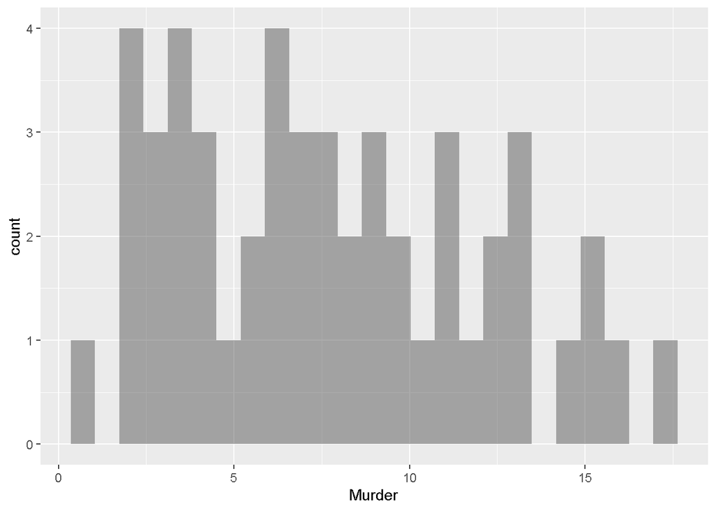

```r
# First consider the USArrests Data.
# Samples (n) = 50, and 4 variables:
# 1. Number of Murder arrests /100,000,
# 2. Number of Assault arrests /100,000
# 3. Percent of urban pop,
# 4. Number of rape arrests /100,000

ggformula::gf_histogram(~Murder, data = USArrests)
```

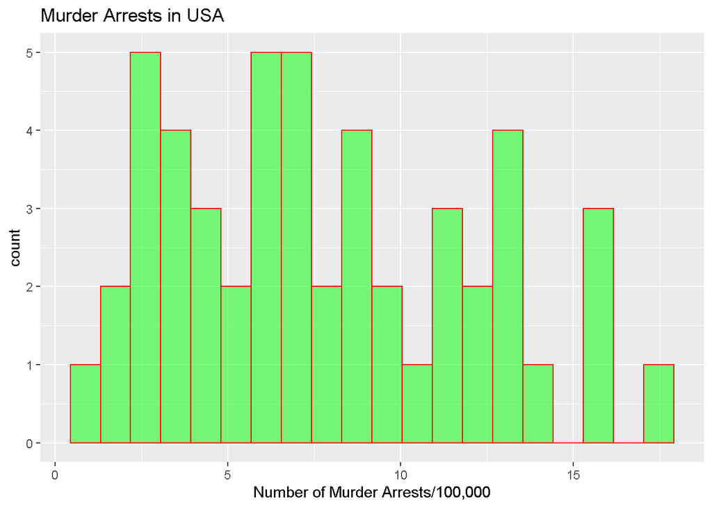

```r
# Histogram with some options
ggformula::gf_histogram(~Murder, data = USArrests, bins = 20,
                        fill = "green", color = "red",
                        title = "Murder Arrests in USA",
                        xlab = "Number of Murder Arrests/100,000")
```

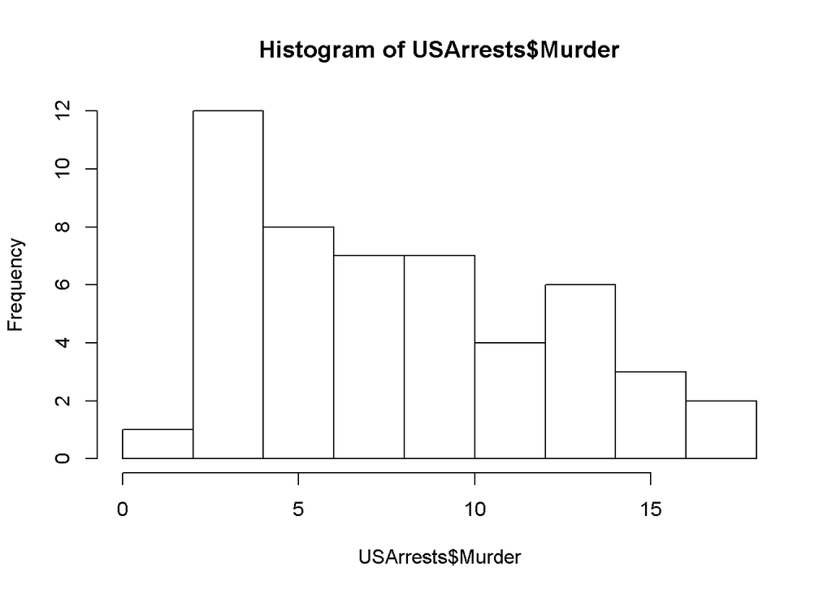

```r
# Using base-R
hist(USArrests$Murder)
```

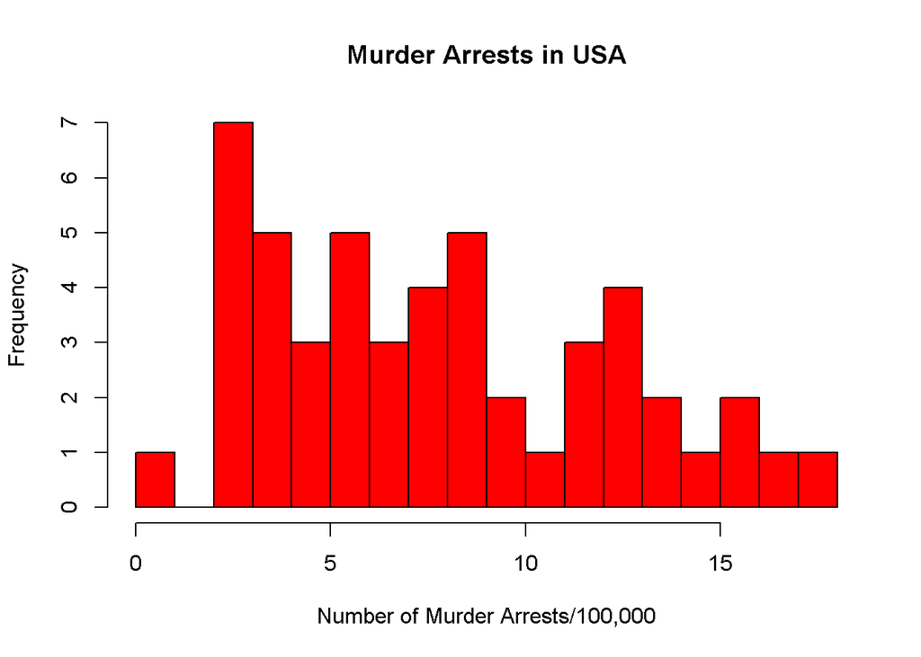

```r
# With options
hist(USArrests$Murder, col = "red", xlab = "Number of Murder Arrests/100,000", main = "Murder Arrests in USA", breaks = 20)
```

### Box plots

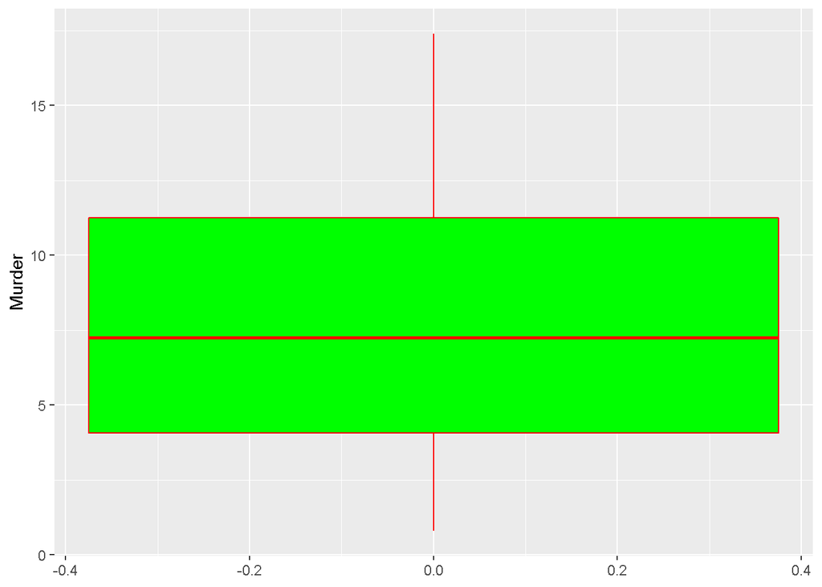

```r
# Simple boxplot using ggformula and base-R
ggformula::gf_boxplot(~Murder, data = USArrests,
                      color = "red", fill = "green")
```

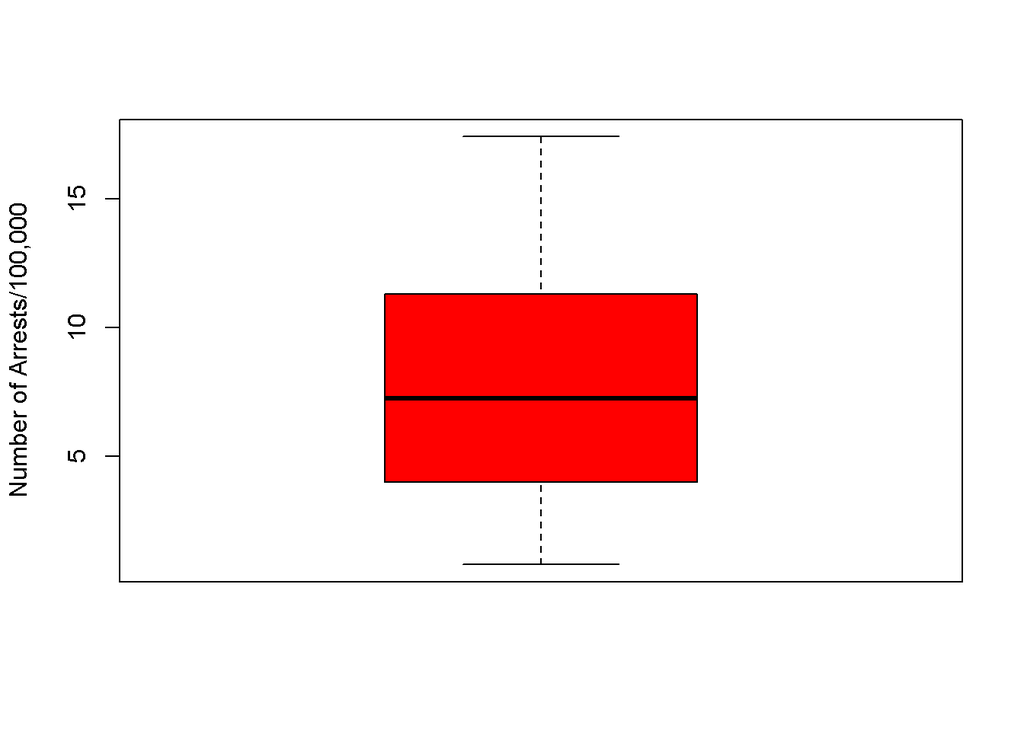

```r
boxplot(USArrests$Murder,
        xlab = "",
        ylab = "Number of Arrests/100,000", col = 2)
```

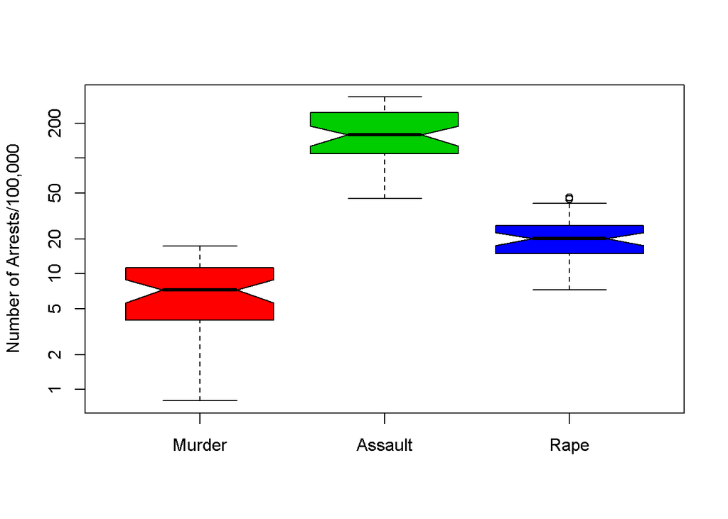

```r
# Easy to do multiple boxplots in base-R
boxplot(list(USArrests$Murder, USArrests$Assault, USArrests$Rape),
        names = c("Murder", "Assault", "Rape"), notch = TRUE,
        ylab = "Number of Arrests/100,000", col = 2:4,
        log = "y") # log = "y", log-scales the y-axis.
```

### Continuous vs. Categorical: boxplots

- Boxplots can be made by a categorical variable
- We look at the `esoph` data now:
  - `agegp`, `alcgp` and `tobgp`: 3 categorical variables for age, alcohol consumption and tobacco consumption.
  - `ncases`: number of cases of esophageal cancer
  - `ncontrols`: number of controls

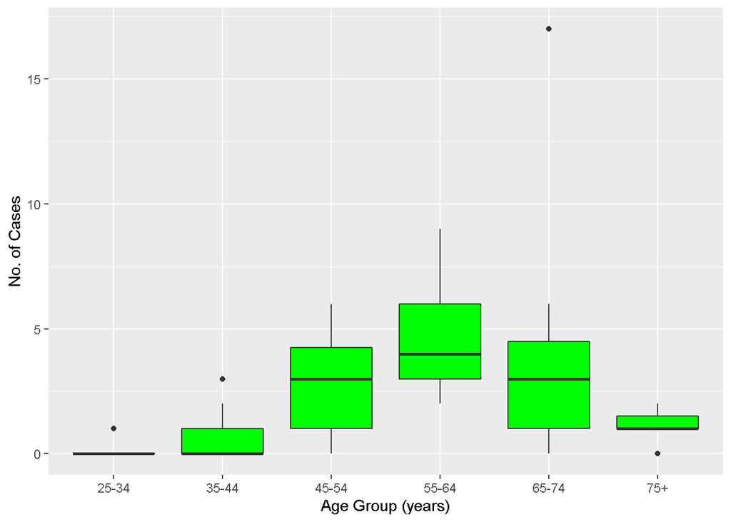

```r
# No. of cases by age group
ggformula::gf_boxplot(ncases~agegp, data = esoph, fill = "green",
                      xlab = "Age Group (years)", ylab = "No. of Cases")
```

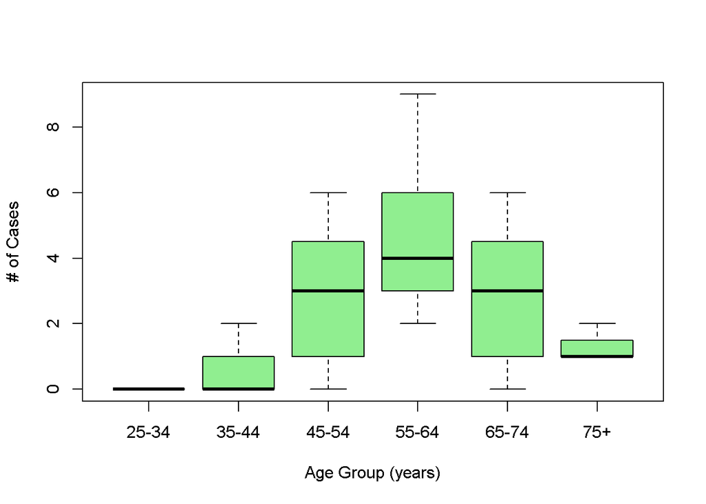

```r
boxplot(ncases ~ agegp, data = esoph, col = "lightgreen",
        xlab = "Age Group (years)", ylab = "# of Cases",
        outline = FALSE)
```

#### Faceting: a very useful feature

- Faceting is a useful feature when we might have multiple variable we wish to group by
- An easy feature for `ggformula` and `ggplot` but harder to do in base-R.

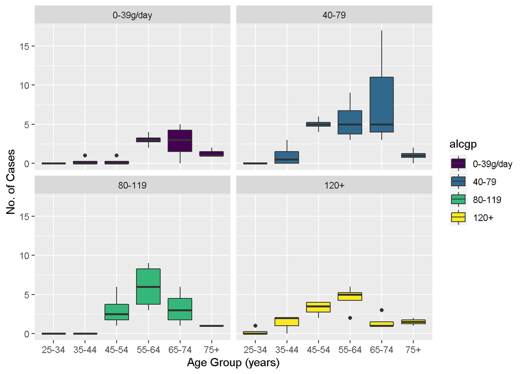

```r
ggformula::gf_boxplot(ncases ~ agegp | alcgp,
                      data = esoph, fill = ~alcgp,
                      xlab = "Age Group (years)", ylab = "No. of Cases")
```

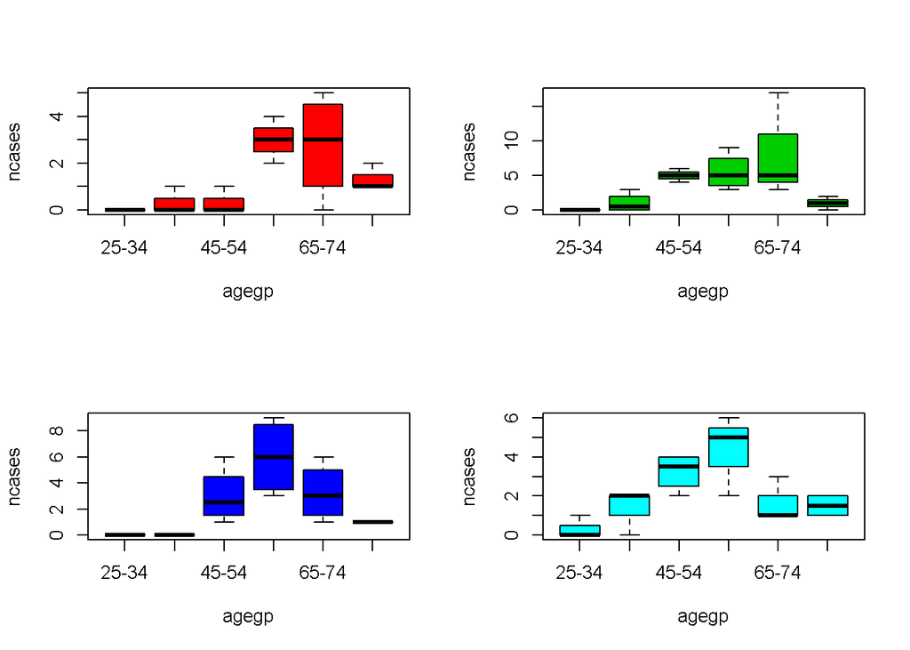

```r
par(mfrow = c(2,2))
boxplot(ncases ~ agegp, data = esoph, subset = (alcgp == "0-39g/day"),
        col = 2)
boxplot(ncases ~ agegp, data = esoph, subset = (alcgp == "40-79"),
        col = 3)
boxplot(ncases ~ agegp, data = esoph, subset = (alcgp == "80-119"),
        col = 4)
boxplot(ncases ~ agegp, data = esoph, subset = (alcgp == "120+"),
        col = 5)
```

```r
par(mfrow = c(1,1))
```